Regresar a la página principal

# Regresion Lineal

# Enunciado

En el dataset encontrarán valores de materia seca obtenidos mediante tres metodologías diferentes que actualmente empleamos en el programa de yuca:

1. DM_raw: Materia seca usando la metodología de horno convencional.
2. DM_gravity: Materia seca por el método gravimétrico.

Para más detalles, pueden ver el siguiente video: Metodo Gravimétrico DM_nirs: Materia seca usando espectroscopía NIR (Near-infrared). Más información en el video desde el minuto 2:27: Espectroscopía NIR

# Tarea:

Seleccionen dos variables y apliquen el mismo pipeline de regresión lineal que revisamos en clase. Recuerden que este es un conjunto de datos reales y contiene valores faltantes, por lo que deben utilizar el argumento de observaciones completas dentro de la función cor. Deben entregarlo en formato informe usando Rmarkdown.

Además, cuando necesiten unir el dataset crudo con las predicciones y las bandas de confianza, asegúrense de eliminar primero todas las filas que contengan valores faltantes. Pueden utilizar los siguientes códigos:

data_cruda %>% filter(!is.na()) %>% bind_cols(predict(…)) data_cruda %>% drop_na() %>% bind_cols(predict(…))

# Cargando los datos

```r
# Cargando las librerías necesarias

library(tidyverse)
library(ggpubr)
library(readr)

Materia_seca <- read.csv("dm_data.csv")
print(head(Materia_seca))
```

```
##                          plot_name accession_name DM_raw DM_gravity DM_nirs
## 1   202109DVGN6_momi_rep1_ARG55_83          ARG55  39.41       35.6    38.9
## 2   202109DVGN6_momi_rep1_ARG65_42          ARG65  37.92       34.3    38.8
## 3  202109DVGN6_momi_rep1_ARG67_107          ARG67  35.26       34.2    34.1
## 4   202109DVGN6_momi_rep1_BOL1_135           BOL1  30.72       30.1    30.8
## 5 202109DVGN6_momi_rep1_BRA1001_71        BRA1001  37.28       34.1    36.3
## 6 202109DVGN6_momi_rep1_BRA1081_11        BRA1081  32.30       32.4    33.6
```

```r
print(tail(Materia_seca))
```

```
##                             plot_name accession_name   DM_raw DM_gravity
## 1281   202101DVGN6_ciat_rep2_USA2_233           USA2 32.94349   36.70857
## 1282   202101DVGN6_ciat_rep2_USA5_236           USA5 37.44100   35.11073
## 1283 202101DVGN6_ciat_rep2_VEN128_239         VEN128 36.35951   36.69617
## 1284 202101DVGN6_ciat_rep2_VEN208_150         VEN208 36.97320   34.72979
## 1285  202101DVGN6_ciat_rep2_VEN25_211          VEN25 35.23612   38.35291
## 1286 202101DVGN6_ciat_rep2_VEN312_192         VEN312 33.55062   35.38164
##       DM_nirs
## 1281 33.45413
## 1282 35.89616
## 1283 37.10273
## 1284 36.29892
## 1285 34.84373
## 1286 34.72980
```

# Grafico multivariado

A continuación presentamos un gráfico, en el que se puede ver la tendencia de los datos

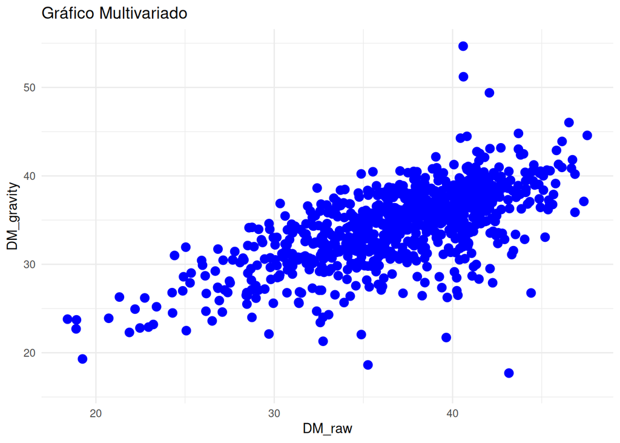

```r
# Gráfico multivariado
ggplot(Materia_seca, aes(x = DM_raw, y = DM_gravity, z = DM_nirs)) +
  geom_point(color = "blue", size = 3) +
  labs(x = "DM_raw", y = "DM_gravity", z = "DM_nirs", title = "Gráfico Multivariado") +
  theme_minimal()
```

# Análisis de correlación

Vamos a hacer la matriz de correlación entre dos columnas, DM_raw y DM_gravity

```r
# Calcular la matriz de correlación entre DM_raw y DM_gravity
correlacion <- cor(Materia_seca$DM_raw, Materia_seca$DM_gravity,use = "complete.obs")

# Imprimir la matriz de correlación
print(correlacion)
```

```
## [1] 0.6568777
```

Un valor de correlación de aproximadamente $0.657$ indica una correlación positiva moderada entre las variables DM_raw y DM_gravity. Lo que significa que, en general, cuando una variable aumenta, la otra también tiende a aumentar, y viceversa. Sin embargo, como la correlación no es tan cercana a 1, se puede apreciar que la relación entre estas dos variables no es exacta y seguro hay cierta variabilidad no explicada por la relación lineal entre ellas.

```r
#Vamos a sacar las dos columnas
# Seleccionar las columnas DM_raw y DM_gravity
datos_seleccionados <- Materia_seca %>%  select(DM_raw, DM_gravity)

# Ver las primeras filas de los datos seleccionados
head(datos_seleccionados)
```

```
##   DM_raw DM_gravity
## 1  39.41       35.6
## 2  37.92       34.3
## 3  35.26       34.2
## 4  30.72       30.1
## 5  37.28       34.1
## 6  32.30       32.4
```

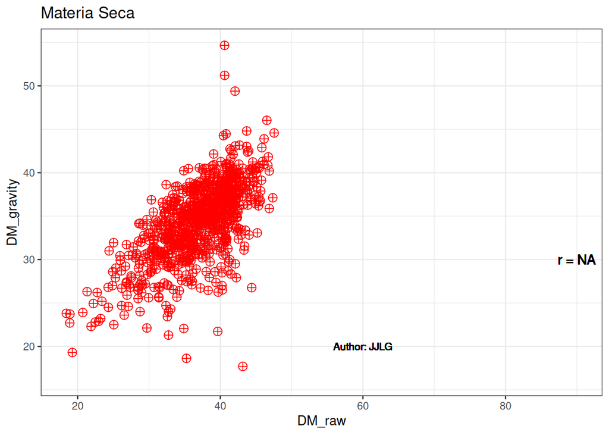

```r
# Gráfico de scatter
ggplot(data = datos_seleccionados, aes(x = DM_raw, y = DM_gravity)) +
  geom_point(size = 3, colour = "red", shape = 10) +
  geom_text(aes(label = paste("r =", round(cor(DM_raw, DM_gravity), 3)), x = 90, y = 30)) +
  geom_text(aes(label = "Author: JJLG"), x = 60, y = 20, size = 3) +
  labs(x = "DM_raw", y = "DM_gravity", title = "Materia Seca") +
  theme_bw()
```

# Modelo lineal

Ahora vamos a determinar el modelo

```r
modelo <- lm(DM_raw ~ DM_gravity, data = datos_seleccionados)
summary(modelo)
```

```
##
## Call:
## lm(formula = DM_raw ~ DM_gravity, data = datos_seleccionados)
##
## Residuals:
##      Min       1Q   Median       3Q      Max
## -11.1974  -2.5194   0.1161   2.3385  18.4420
##
## Coefficients:
##             Estimate Std. Error t value Pr(>|t|)
## (Intercept) 11.75407    1.00178   11.73   <2e-16 ***
## DM_gravity   0.73243    0.02894   25.31   <2e-16 ***
## ---
## Signif. codes:  0 '***' 0.001 '**' 0.01 '*' 0.05 '.' 0.1 ' ' 1
##
## Residual standard error: 3.709 on 844 degrees of freedom
##   (440 observations deleted due to missingness)
## Multiple R-squared:  0.4315, Adjusted R-squared:  0.4308
## F-statistic: 640.6 on 1 and 844 DF,  p-value: < 2.2e-16
```

```r
anova(modelo)
```

```
## Analysis of Variance Table
##
## Response: DM_raw
##             Df  Sum Sq Mean Sq F value    Pr(>F)
## DM_gravity   1  8814.5  8814.5  640.58 < 2.2e-16 ***
## Residuals  844 11613.7    13.8
## ---
## Signif. codes:  0 '***' 0.001 '**' 0.01 '*' 0.05 '.' 0.1 ' ' 1
```

# Valores ajustados

```r
# fitted values
modelo$fitted.values
```

[output not shown]

[output cut: 157 more lines]

[output not shown]

```r
# errores
modelo$residuals
```

[output not shown]

[output cut: 285 more lines]

[output not shown]

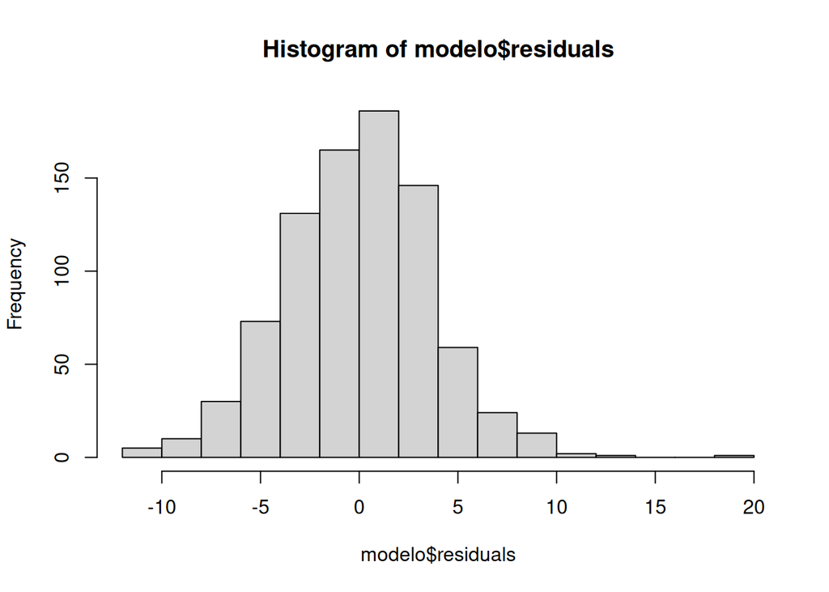

```r
hist(modelo$residuals)
```

Se aprecia que los residuos siguen una distribución aproximadamente normal.

```r
# Coeficientes
b0 = modelo$coefficients[1]###intercepto en y
b1 = modelo$coefficients[2]#Pendiente

#inpresion de los coeficientes
print(b0)
```

```
## (Intercept)
##    11.75407
```

```r
print(b1)
```

```
## DM_gravity
##  0.7324279
```